# R bootcamp, Module 7: Core tools

August 2013, UC Berkeley

Chris Paciorek

# Optimization

Note to BB: remember to start recording.

R provides functionality for optimization - finding maxima or minima of a function.

A workhorse is `optim()`, which implements a number of optimization algorithms.

```r
require(fields)
```

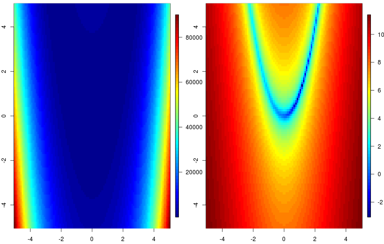

```r
banana <- function(x) {
    ## Rosenbrock Banana function
    x1 <- x[1]
    x2 <- x[2]
    100 * (x2 - x1 * x1)^2 + (1 - x1)^2
}

x1s <- x2s <- seq(-5, 5, length = 100)
x <- expand.grid(x1s, x2s)
fx <- apply(x, 1, banana)

par(mfrow = c(1, 2), mai = c(0.45, 0.4, 0.1, 0.4))
image.plot(x1s, x2s, matrix(fx, 100), xlab = "", ylab = "")
image.plot(x1s, x2s, matrix(log(fx), 100), xlab = "", ylab = "")
```

```r
optim(c(-2, 0), banana)
```

```
## $par
## [1] 1.003 1.006
##
## $value
## [1] 2.08e-05
##
## $counts
## function gradient
##      181       NA
##
## $convergence
## [1] 0
##
## $message
## NULL
```

We can see the progression of evaluations of the objective function:

```r
banana <- function(x) {
    ## Rosenbrock Banana function
    points(x[1], x[2])
    Sys.sleep(0.03)
    x1 <- x[1]
    x2 <- x[2]
    100 * (x2 - x1 * x1)^2 + (1 - x1)^2
}
par(mfrow = c(1, 1), mai = c(0.45, 0.4, 0.1, 0.4))
image.plot(x1s, x2s, matrix(log(fx), 100), xlab = "", ylab = "")
optim(c(-2, 0), banana)
```

# Smoothing

Linear regression and GLMs are of course useful, but often the relationship is not linear, even on some transformed scale.

Additive models and generalized additive models (GAMs) are the more flexible variants on linear models and GLMs.

There are a variety of tools in R for modeling nonlinear and smooth relationships, mirroring the variety of methods in the literature.

One workhorse is `gam()` in the *mgcv* package.

# GAM in action

Let's consider height in the earnings dataset.

Any hypotheses about the relationship of earnings with height and education?

```r
library(mgcv)
runif(1)  # not clear why this is needed; knitr throws error w/out it
```

```
## [1] 0.2015
```

```r
mod_male <- gam(earn ~ s(height, k = 10) + s(ed, k = 10), data = earnings[earnings$sex ==
    1, ])
mod_female <- gam(earn ~ s(height, k = 10) + s(ed, k = 10), data = earnings[earnings$sex ==
    2, ])
summary(mod_male)
```

```
##
## Family: gaussian
## Link function: identity
##
## Formula:
## earn ~ s(height, k = 10) + s(ed, k = 10)
## <environment: 0xdb64c8>
##
## Parametric coefficients:
##             Estimate Std. Error t value Pr(>|t|)
## (Intercept)    28927        940    30.8   <2e-16 ***
## ---
## Signif. codes:  0 '***' 0.001 '**' 0.01 '*' 0.05 '.' 0.1 ' ' 1
##
## Approximate significance of smooth terms:
##            edf Ref.df     F p-value
## s(height) 1.00   1.00  3.11   0.078 .
## s(ed)     4.93   5.94 17.04  <2e-16 ***
## ---
## Signif. codes:  0 '***' 0.001 '**' 0.01 '*' 0.05 '.' 0.1 ' ' 1
##
## R-sq.(adj) =  0.168   Deviance explained = 17.8%
## GCV score = 4.6545e+08  Scale est. = 4.5925e+08  n = 520
```

```r
summary(mod_female)
```

```
##
## Family: gaussian
## Link function: identity
##
## Formula:
## earn ~ s(height, k = 10) + s(ed, k = 10)
## <environment: 0xdb64c8>
##
## Parametric coefficients:
##             Estimate Std. Error t value Pr(>|t|)
## (Intercept)    14620        467    31.3   <2e-16 ***
## ---
## Signif. codes:  0 '***' 0.001 '**' 0.01 '*' 0.05 '.' 0.1 ' ' 1
##
## Approximate significance of smooth terms:
##            edf Ref.df     F p-value
## s(height) 1.00   1.00  0.51    0.47
## s(ed)     2.16   2.73 47.62  <2e-16 ***
## ---
## Signif. codes:  0 '***' 0.001 '**' 0.01 '*' 0.05 '.' 0.1 ' ' 1
##
## R-sq.(adj) =  0.134   Deviance explained = 13.7%
## GCV score = 1.8821e+08  Scale est. = 1.873e+08  n = 859
```

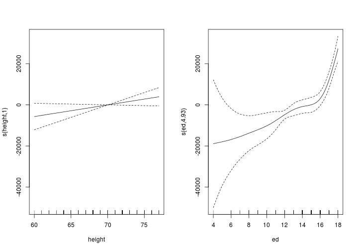

```r
par(mfrow = c(1, 2))
plot(mod_male)
```

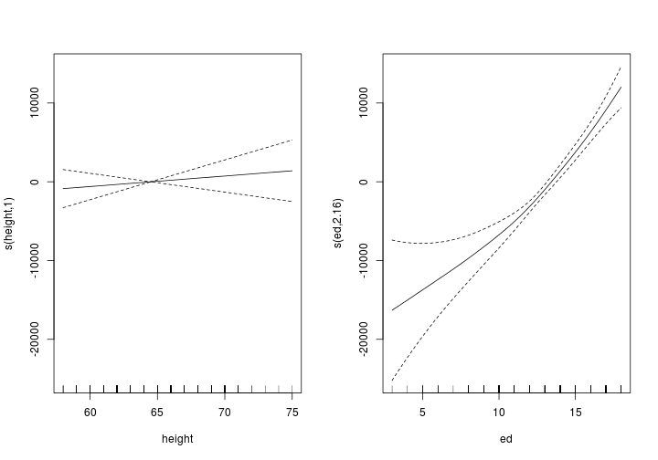

```r
plot(mod_female)
```

# A bit more model-building

Suppose we want to account for race in the model.

```r
mod_male_full <- gam(earn ~ s(height, k = 10) + s(ed, k = 10) + race, data = earnings[earnings$sex ==
    1, ])
mod_female_full <- gam(earn ~ s(height, k = 10) + s(ed, k = 10) + race, data = earnings[earnings$sex ==
    2, ])
summary(mod_male_full)
```

```
##
## Family: gaussian
## Link function: identity
##
## Formula:
## earn ~ s(height, k = 10) + s(ed, k = 10) + race
## <environment: 0xdb64c8>
##
## Parametric coefficients:
##             Estimate Std. Error t value Pr(>|t|)
## (Intercept)    34098       2165   15.75   <2e-16 ***
## race           -4459       1684   -2.65   0.0083 **
## ---
## Signif. codes:  0 '***' 0.001 '**' 0.01 '*' 0.05 '.' 0.1 ' ' 1
##
## Approximate significance of smooth terms:
##            edf Ref.df    F p-value
## s(height) 1.00   1.00  2.1    0.15
## s(ed)     4.81   5.82 17.6  <2e-16 ***
## ---
## Signif. codes:  0 '***' 0.001 '**' 0.01 '*' 0.05 '.' 0.1 ' ' 1
##
## R-sq.(adj) =  0.177   Deviance explained = 18.8%
## GCV score = 4.6118e+08  Scale est. = 4.5425e+08  n = 520
```

```r
summary(mod_female_full)
```

```
##
## Family: gaussian
## Link function: identity
##
## Formula:
## earn ~ s(height, k = 10) + s(ed, k = 10) + race
## <environment: 0xdb64c8>
##
## Parametric coefficients:
##             Estimate Std. Error t value Pr(>|t|)
## (Intercept)    13748        928   14.81   <2e-16 ***
## race             741        682    1.09     0.28
## ---
## Signif. codes:  0 '***' 0.001 '**' 0.01 '*' 0.05 '.' 0.1 ' ' 1
##
## Approximate significance of smooth terms:
##            edf Ref.df     F p-value
## s(height) 1.00   1.00  0.64    0.43
## s(ed)     2.74   3.44 37.69  <2e-16 ***
## ---
## Signif. codes:  0 '***' 0.001 '**' 0.01 '*' 0.05 '.' 0.1 ' ' 1
##
## R-sq.(adj) =  0.134   Deviance explained = 13.9%
## GCV score = 1.8844e+08  Scale est. = 1.8718e+08  n = 859
```

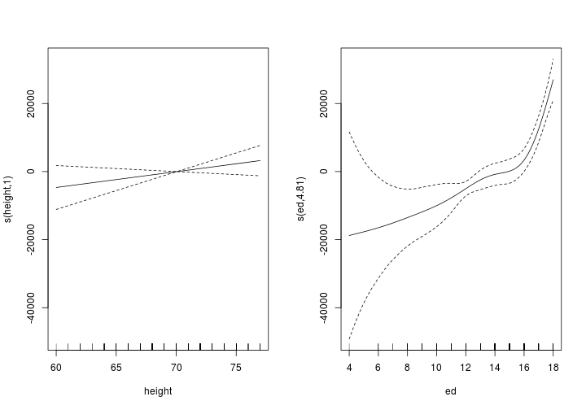

```r
par(mfrow = c(1, 2))
plot(mod_male_full)
```

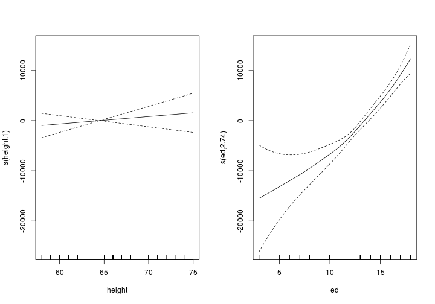

```r
plot(mod_female_full)
```

Comments?

# Distributions

Since R was developed by statisticians, it handles distributions and simulation seamlessly.

All commonly-used distributions have functions in R. Each distribution has a family of functions:

- d - probability density/mass function, e.g. `dnorm()`
- r - generate a random value, e.g., `rnorm()`
- p - cumulative distribution function, e.g., `pnorm()`
- q - quantile function (inverse CDF), e.g., `qnorm()`

Some of the distributions include the following (in the form of their random number generator function): `rnorm()`, `runif()`, `rbinom()`, `rpois()`, `rbeta()`, `rgamma()`, `rt()`.

# Distributions in action

```r
pnorm(1.96)
```

```
## [1] 0.975
```

```r
qnorm(0.975)
```

```
## [1] 1.96
```

```r
dbinom(0:10, size = 10, prob = 0.3)
```

```
##  [1] 2.825e-02 1.211e-01 2.335e-01 2.668e-01 2.001e-01 1.029e-01 3.676e-02
##  [8] 9.002e-03 1.447e-03 1.378e-04 5.905e-06
```

```r
dnorm(5)
```

```
## [1] 1.487e-06
```

```r
dt(5, df = 1)
```

```
## [1] 0.01224
```

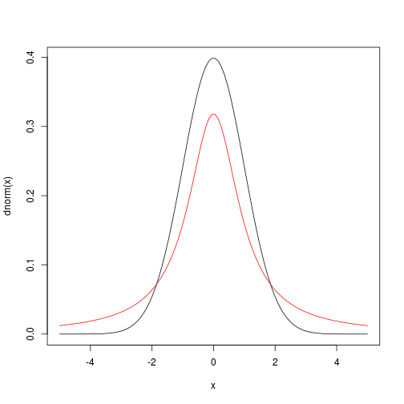

```r
x <- seq(-5, 5, length = 100)
plot(x, dnorm(x), type = "l")
lines(x, dt(x, df = 1), col = "red")
```

```r
rmultinom(1, 100, prob = c(0.1, 0.1, 0.2, 0.3, 0.25, 0.05))
```

```
##      [,1]
## [1,]   12
## [2,]    8
## [3,]   25
## [4,]   26
## [5,]   26
## [6,]    3
```

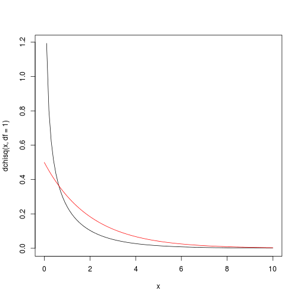

```r
x <- seq(0, 10, length = 100)
plot(x, dchisq(x, df = 1), type = "l")
lines(x, dchisq(x, df = 2), col = "red")
```

# Other types of simulation and sampling

We can draw a sample with or without replacement. Here's an example of some code that would be part of coding up a bootstrap.

```r
sample(row.names(state.x77), 7, replace = FALSE)
```

```
## [1] "Oklahoma"       "Kansas"         "Florida"        "Mississippi"
## [5] "Missouri"       "Maryland"       "North Carolina"
```

```r
mean(earnings$earn, na.rm = TRUE)
```

```
## [1] 20015
```

```r
# here's a bootstrap sample:
smp <- sample(seq_len(nrow(earnings)), replace = TRUE)
mean(earnings$earn[smp], na.rm = TRUE)
```

```
## [1] 20798
```

It's a good idea to use `seq_along()` and `seq_len()` and not syntax like `1:length(earnings)` in `sample()` because the outcome of `length()` might in some cases be unexpected (e.g., if you're taking subsets of a dataset). Similar reasoning holds when setting up for loops: e.g.,

```r
for (i in seq_len(nrow(earnings))) {
    # blah
}
```

# The Random Seed

A few key facts about generating random numbers

- Random number generation is based on generating uniformly between 0 and 1 and then transforming to the kind of random number of interest: normal, categorical, etc.
- Random numbers on a computer are *pseudo-random*; they are generated deterministically from a very, very, very long sequence that repeats
- The *seed* determines where you are in that sequence

To replicate any work involving random numbers, make sure to set the seed first.

```r
set.seed(0)
vals <- rnorm(10)
vals
```

```
##  [1]  1.262954 -0.326233  1.329799  1.272429  0.414641 -1.539950 -0.928567
##  [8] -0.294720 -0.005767  2.404653
```

```r
vals <- rnorm(10)
vals
```

```
##  [1]  0.7636 -0.7990 -1.1477 -0.2895 -0.2992 -0.4115  0.2522 -0.8919
##  [9]  0.4357 -1.2375
```

```r
set.seed(0)
vals <- rnorm(10)
vals
```

```
##  [1]  1.262954 -0.326233  1.329799  1.272429  0.414641 -1.539950 -0.928567
##  [8] -0.294720 -0.005767  2.404653
```

# Dates

- R has built-in ways to handle dates (don't reinvent the wheel!)

```r
date1 <- as.Date("03-01-2011", format = "%m-%d-%Y")
date2 <- as.Date("03/02/11", format = "%m/%d/%y")
date3 <- as.Date("07-May-11", format = "%d-%b-%y")

date1
```

```
## [1] "2011-03-01"
```

```r
date2
```

```
## [1] "2011-03-02"
```

```r
class(date1)
```

```
## [1] "Date"
```

```r
dates <- c(date1, date2, date3)
weekdays(dates)
```

```
## [1] "Tuesday"   "Wednesday" "Saturday"
```

```r
dates + 30
```

```
## [1] "2011-03-31" "2011-04-01" "2011-06-06"
```

```r
date3 - date2
```

```
## Time difference of 66 days
```

```r
unclass(dates)
```

```
## [1] 15034 15035 15101
```

- The origin date in R is January 1, 1970

# Time too!

```r
library(chron)
d1 <- chron("12/25/2004", "10:37:59")
# default format of m/d/Y and h:m:s
d2 <- chron("12/26/2004", "11:37:59")

class(d1)
```

```
## [1] "chron" "dates" "times"
```

```r
d1
```

```
## [1] (12/25/04 10:37:59)
```

```r
d1 + 33
```

```
## [1] (01/27/05 10:37:59)
```

```r
d2 - d1
```

```
## Time in days:
## [1] 1.042
```

```r
d1 + d2
```

```
## Error: chron objects may not be added together
```

There's lots more packages/functionality for dates/times: see *lubridate* and `?DateTimeClasses`

# Breakout

1. Suppose you wanted to do 10-fold cross-validation for some sort of regression model fit to the *earnings* dataset. Write some R code that produces a field in the dataset that indicates which fold each observation is in. Ensure each of the folds has an equal (or as nearly equal as possible if the number of observations is not divisible by 10) number of observations. Hint: consider the *times* argument to the `rep()` function.
2. Write some code to demonstrate the central limit theorem. Generate many different replicates of samples of size `n` from a skewed or discrete distribution and show that if `n` is big enough, the distribution of the means (of each sample of size `n`) looks approximately normal in a histogram. Do it without any looping!

I.e., I want you to show that if you have a large number (say 10,000) of means, each mean being the mean of `n` values from a distribution, the distribution of the means looks approximately normal if `n` is sufficiently big.